# Reproducible Research: Peer Assessment 1

## Loading and preprocessing the data

```r
# Read data
activity <- read.csv("activity.csv")
# Remove NAs
activityClean <- activity[complete.cases(activity),]
```

## What is the mean total number of steps taken per day?

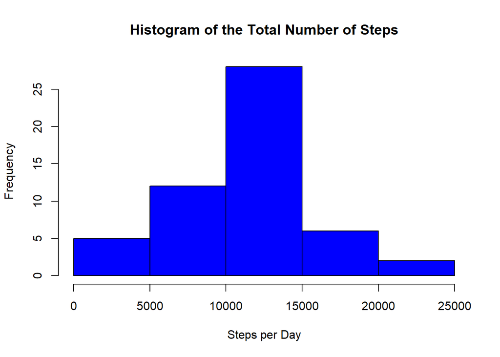

```r
library(dplyr)
# Calculate the total number of steps taken per day
sumSteps <- aggregate(steps~date,activityClean,sum)
# Make a histogram of the total number of steps taken each day
histSteps <- hist(sumSteps$steps, main="Histogram of the Total Number of Steps", xlab="Steps per Day",col="blue")
```

```r
# Calculate and report the mean and median of the total number of steps taken per day
library(scales)
meanClean <- mean(sumSteps$steps)
meanClean <- comma_format(digits=5)(meanClean)
medianClean <- median(sumSteps$steps)
medianClean <- comma(medianClean)
```

- The `mean` of the total number of steps taken per day is **10,766.**
- The `median` of the total number of steps taken per day is **10,765.**

## What is the average daily activity pattern?

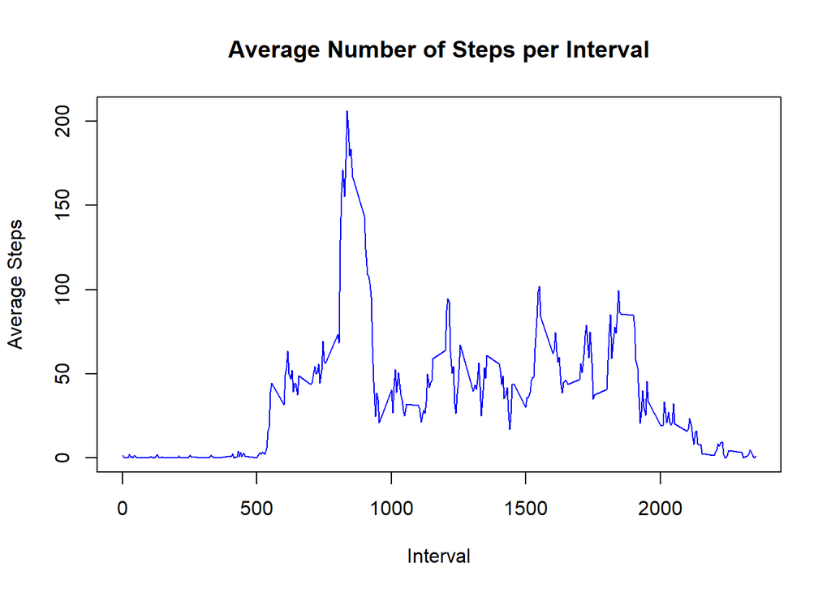

```r
# Make a time series plot of the 5-minute interval
meanSteps <- aggregate(steps~interval,activityClean,mean)
plot(meanSteps$interval,meanSteps$steps,type="l",main="Average Number of Steps per Interval",xlab="Interval",ylab="Average Steps",col="blue")
```

The interval that contains the maximum number of steps is:

```r
maxInterval <- meanSteps[which.max(meanSteps$steps),]
maxInterval
```

```
##     interval    steps
## 104      835 206.1698
```

## Imputing missing values

```r
# Compute total number of missing values
TotalMissing <- sum(is.na(activity))
TotalMissing <- comma(TotalMissing)
```

- The total number of missing values is **2,304**.
- To fill in all missing values, the strategy is to replace them with the average steps calculated per interval as shown below.

```r
# Fill in all missing values based on the average steps per interval
for (i in 1:nrow(activity)) {
  if(is.na(activity$steps[i])) {
    value <- meanSteps$steps[which(meanSteps$interval == activity$interval[i])]
    activity$steps[i] <- value
  }
}
activity$steps <- round(activity$steps,digits=0)
```

- The histogram of the new dataset with imputed values is then compared to the histogram of the old dataset where the null values are removed.

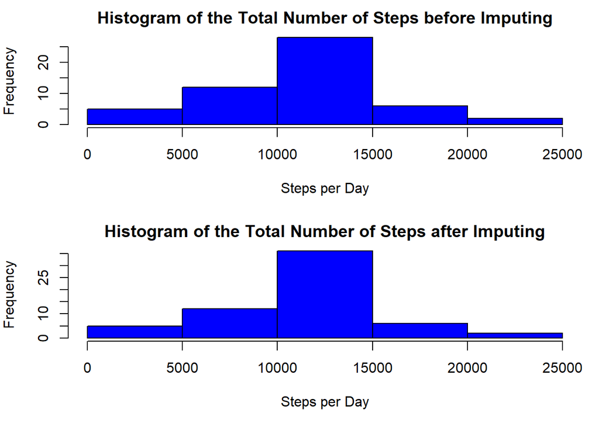

```r
# Recalculate the mean, median, and histogram with imputed values
sumStepsImputed <- aggregate(steps~date,activity,sum)

# Make a histogram of the total number of steps taken each day with imputed values
par(mfrow=c(2,1),mar=c(5,4,2,1))
histSteps <- hist(sumSteps$steps, main="Histogram of the Total Number of Steps before Imputing", xlab="Steps per Day",col="blue")
histStepsImputed <- hist(sumStepsImputed$steps, main="Histogram of the Total Number of Steps after Imputing",xlab="Steps per Day",col="blue")
```

```r
# Calculate and report the mean and median of the total number of steps taken per day wuth imputed values
meanImputed <- mean(sumStepsImputed$steps)
meanImputed <- comma_format(digits=5)(meanImputed)
medianImputed <- median(sumStepsImputed$steps)
medianImputed <- comma(medianImputed)
```

- The `mean` of the new dataset is **10,766** vs the old mean of **10,766**.
- The `median` of the new dataset is **10,762** vs the old median of **10,765**.
- *It can be observed that in terms of the histogram, mean and median, there is no significant difference between the two datasets.*

## Are there differences in activity patterns between weekdays and weekends?

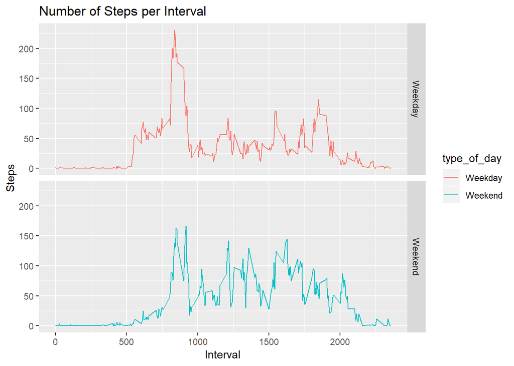

```r
#Create a new factor variable in the dataset with two levels - "weekday" and "weekend" indicating whether a given date is a weekday or weekend day.
library(chron)

for(i in 1:nrow(activity)){ ### Order type of day
  if(is.weekend(activity$date[i])=="TRUE"){
    activity$type_of_day[i]<-"Weekend"
  }
  else {
    activity$type_of_day[i]<-"Weekday"
  }
}

#Make a panel plot containing a time series plot of the 5-minute interval averaged across all weekday days or weekend days (y-axis)
activity$type_of_day <- as.factor(activity$type_of_day)

meanStepsWeekend <- aggregate(steps~interval+type_of_day,activity,mean)
library(ggplot2)
g <- ggplot(meanStepsWeekend, aes(interval, steps))
g + geom_line(stat = "identity", aes(color = type_of_day)) +
  facet_grid(type_of_day~.) +
  labs(x="Interval", y="Steps",title= "Number of Steps per Interval")
```

- It can be observed that the activity pattern during weekends is fluctuating more than weekdays.